# ゲームハード週販レポート (2026.03.22)

国内ゲームハード週販レポート (2026-03-22)

- ハードウェアの販売データはファミ通の調査結果を基にしています。
- 一部のデータは処理上の都合により、週次値に調整しています｡
- 過去の週販レポート

## 直近4週間のハード売り上げ／累計推移

| 集計日 | ハード | 販売台数 | 前週差 | 累計台数 |
| --- | --- | --- | --- | --- |
| 2026-03-01 | Nintendo Switch2 | 85,830 | +22,517 | 4,579,815 |
|  | Nintendo Switch | 22,260 | -6,166 | 36,604,007 |
|  | PlayStation5 | 15,048 | +4,705 | 7,423,770 |
|  | Xbox Series X\|S | 648 | -540 | 695,200 |
|  | PlayStation4 | 35 | -2 | 9,491,232 |
| 2026-03-08 | Nintendo Switch2 | 127,508 | +41,678 | 4,707,323 |
|  | Nintendo Switch | 23,770 | +1,510 | 36,627,777 |
|  | PlayStation5 | 16,819 | +1,771 | 7,440,589 |
|  | Xbox Series X\|S | 486 | -162 | 695,686 |
|  | PlayStation4 | 29 | -6 | 9,491,261 |
| 2026-03-15 | Nintendo Switch2 | 96,950 | -30,558 | 4,804,273 |
|  | Nintendo Switch | 19,941 | -3,829 | 36,647,718 |
|  | PlayStation5 | 12,886 | -3,933 | 7,453,475 |
|  | Xbox Series X\|S | 296 | -190 | 695,982 |
|  | PlayStation4 | 26 | -3 | 9,491,287 |
| 2026-03-22 | Nintendo Switch2 | 81,518 | -15,432 | 4,885,791 |
|  | Nintendo Switch | 18,754 | -1,187 | 36,666,472 |
|  | PlayStation5 | 14,119 | +1,233 | 7,467,594 |
|  | Xbox Series X\|S | 209 | -87 | 696,191 |
|  | PlayStation4 | 19 | -7 | 9,491,306 |

ぽこあポケモンのパッケージは先週とほぼ同数の11万4千本を販売し､累計は77万本に達しました｡ ハードの牽引効果も継続中で､Switch2は今週も8万台を販売しました｡ ブルームバーグの減産報道にかかわらず､少なくとも日本では好調です｡

Switchは微減傾向｡今度こそ､ぽこあポケモン効果で一般層がSwitch2にシフトしている?

PS5は若干増えて1万4千台｡紅の砂漠が3万本売れており､その効果かも知れません｡

## 週販推移

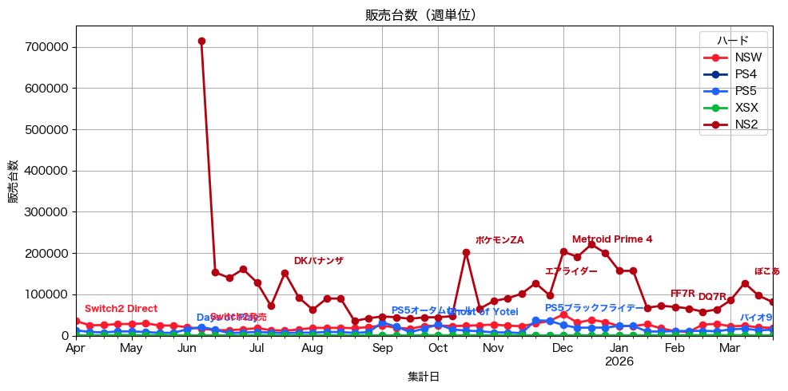

### 週販推移(拡大）

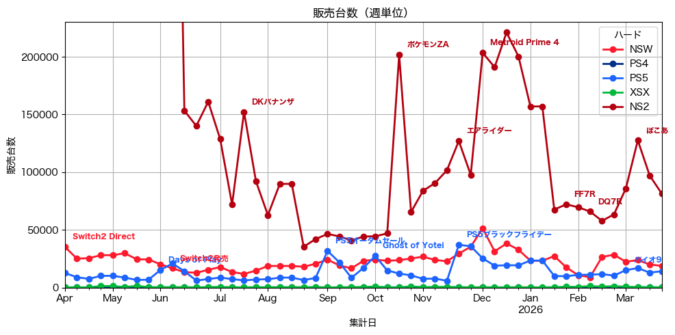

Switch2にぽこあポケモンの効果が乗っていると言っても､ぽこあポケモンの前週8万5千台を既に下回っています｡ 来週のSwitch2は「通常時」に戻りそうです｡

## 直近4年間の同時期週販比較

### PlayStation 5: 2023〜2026 1月15日以降

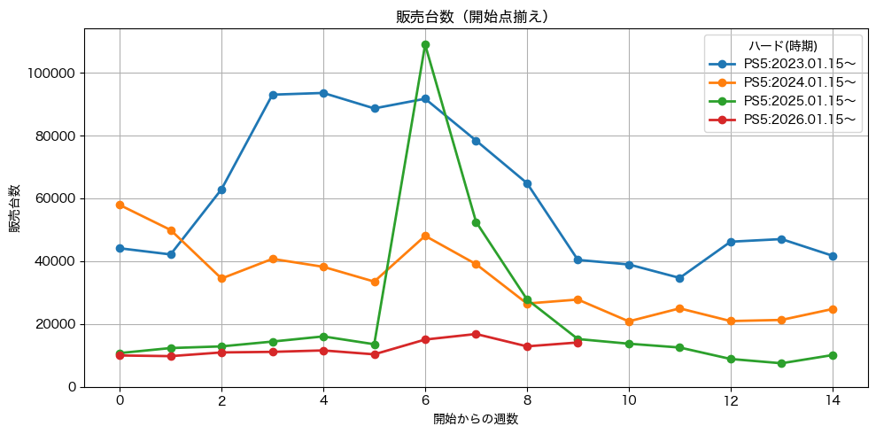

バイオハザードレクイエムの牽引効果は終わり､ 少しだけ紅の砂漠の効果があったようです｡ ただし､1万5千台/週には届いていません｡

欧州でPS5値上げの噂がありますが､日本では果たして?

### Nintendo Switch2: 2026 と Switch 2018,2019,2020年 1月15日以降

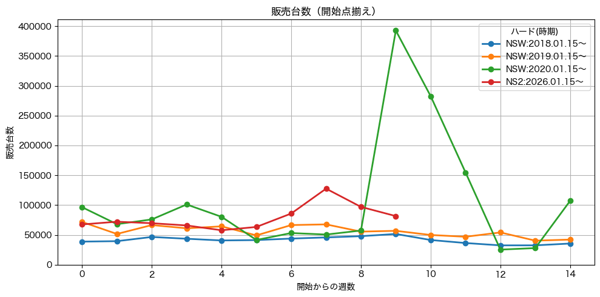

(Switch2は昨年のデータがありませんので､Switchの2018年〜2020年の推移と比較します｡)

ぽこあポケモン牽引効果の余波で､Switch2は2018年､2019年の同時期のNintendo Switchに対して約3万台高い水準で推移しています｡ これが永続するとも思えないので､そろそろSwitch並の5万/週程度に落ち着いても問題ないとは思います｡それでも十分に高水準です｡

## 月間販売推移

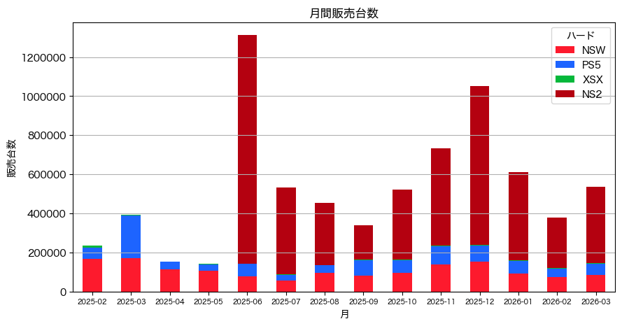

3月の集計はあと1回ありますが､ 既に､月間のハード販売台数としては2025年7月を超える高水準となっています｡

### Nintendo Switch2月間販売台数

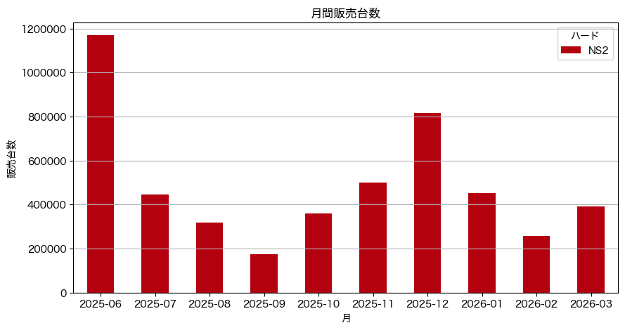

Switch2の3月の月間販売台数は39万台となりました｡ 3月集計はあと1回を残しているので､1月の45万台を超えるのは確実です｡

### Nintendo Switchの月間販売台数： 前々年､前年との比較

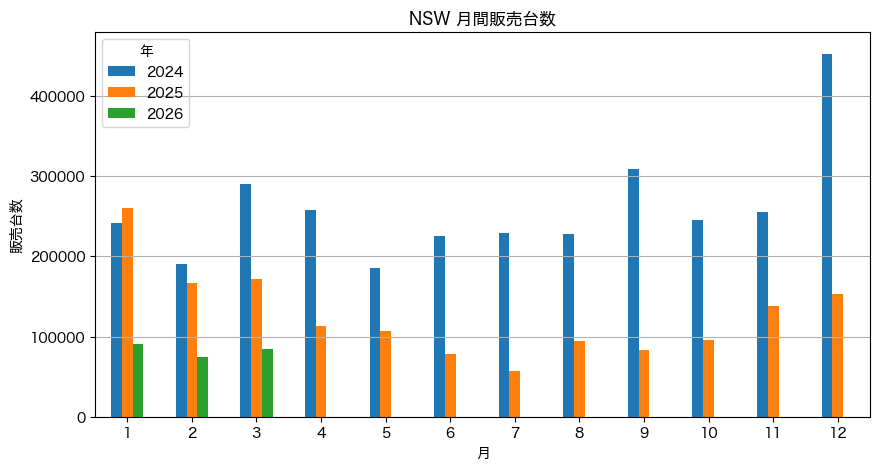

| 月 | 2025 | 2026 | YoY |
| --- | --- | --- | --- |
| 1 | 260,447 | 91,109 | 35.0% |
| 2 | 167,188 | 74,477 | 44.5% |
| 3 | 171,921 | 84,725 | 49.3% |
| 4 | 113,513 | 0 | 0.0% |
| 5 | 106,506 | 0 | 0.0% |
| 6 | 78,097 | 0 | 0.0% |
| 7 | 57,532 | 0 | 0.0% |
| 8 | 94,517 | 0 | 0.0% |
| 9 | 82,946 | 0 | 0.0% |
| 10 | 96,080 | 0 | 0.0% |
| 11 | 138,018 | 0 | 0.0% |
| 12 | 153,619 | 0 | 0.0% |

Switchの3月販売台数は､思ったよりも減らず､最終的に前年比50%を超えそうです｡

### PlayStation 5の月間販売台数： 前々年､前年との比較

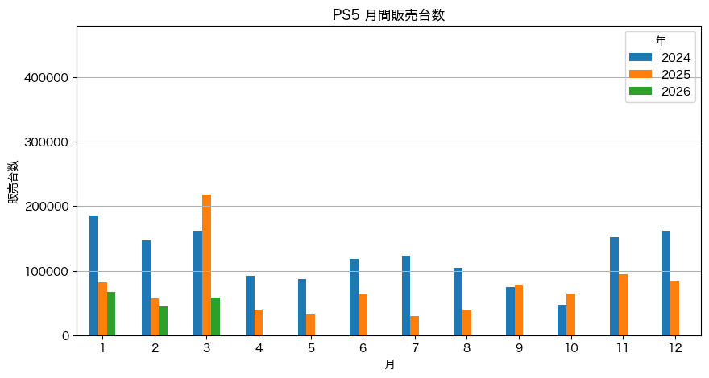

| 月 | 2025 | 2026 | YoY |
| --- | --- | --- | --- |
| 1 | 81,587 | 66,502 | 81.5% |
| 2 | 56,886 | 44,010 | 77.4% |
| 3 | 218,300 | 58,872 | 27.0% |
| 4 | 38,983 | 0 | 0.0% |
| 5 | 32,001 | 0 | 0.0% |
| 6 | 63,516 | 0 | 0.0% |
| 7 | 28,959 | 0 | 0.0% |
| 8 | 39,004 | 0 | 0.0% |
| 9 | 78,693 | 0 | 0.0% |
| 10 | 64,732 | 0 | 0.0% |
| 11 | 93,852 | 0 | 0.0% |
| 12 | 82,691 | 0 | 0.0% |

## 累計販売推移

### Switch2 42週目の状況

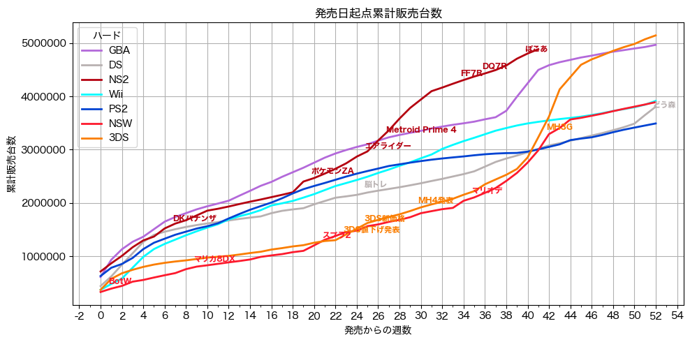

| ハード | 販売数 |
| --- | --- |
| NS2 | 4,885,791 |
| GBA | 4,496,797 |
| Wii | 3,522,861 |
| 3DS | 3,233,571 |
| DS | 3,015,412 |
| PS2 | 3,005,742 |
| NSW | 2,988,399 |

Switch2は42週目で累計488万台｡同時期のSwitchに比べ190万台多い状況です｡ Switch2の500万台到達は再来週､4月5日集計になると思われます｡

### PS5 280週目の状況

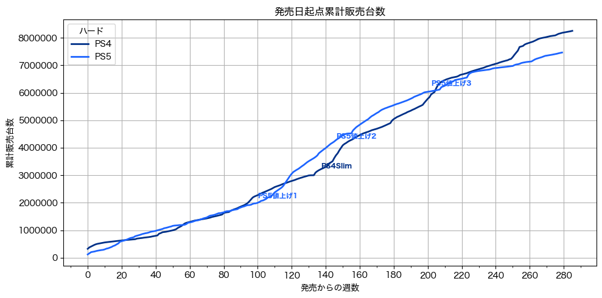

| ハード | 販売数 |
| --- | --- |
| PS4 | 8,184,468 |
| PS5 | 7,467,594 |

PS5は280週目で累計746万台です｡PS4よりも70万台少ない水準が継続しています｡

## 年単位の状況

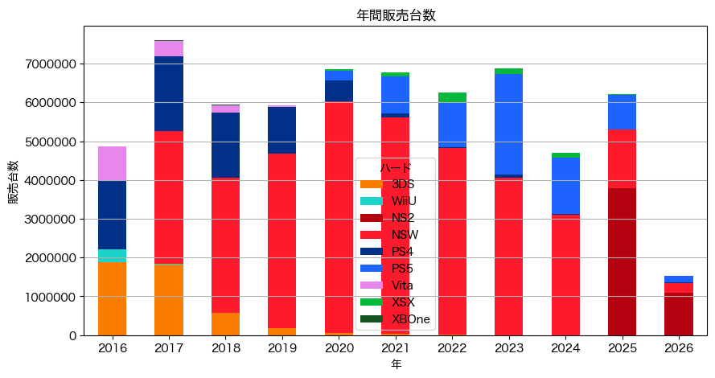

| year | 3DS | WiiU | NS2 | NSW | PS4 | PS5 | Vita | XSX | XBOne | 合計 |
| --- | --- | --- | --- | --- | --- | --- | --- | --- | --- | --- |
| 2016 | 1,874,457 | 336,151 | nan | nan | 1,790,883 | nan | 865,002 | nan | 8,897 | 4,875,390 |
| 2017 | 1,827,131 | 21,817 | nan | 3,407,158 | 1,935,247 | nan | 396,207 | nan | 14,664 | 7,602,224 |
| 2018 | 566,420 | nan | nan | 3,482,388 | 1,695,227 | nan | 181,728 | nan | 15,339 | 5,941,102 |
| 2019 | 191,173 | nan | nan | 4,493,903 | 1,196,153 | nan | 37,668 | nan | 8,315 | 5,927,212 |
| 2020 | 62,761 | nan | nan | 5,956,943 | 542,647 | 255,150 | nan | 31,424 | 3,585 | 6,852,510 |
| 2021 | 28,540 | nan | nan | 5,579,127 | 104,054 | 968,185 | nan | 97,234 | nan | 6,777,140 |
| 2022 | 10,664 | nan | nan | 4,804,546 | 22,823 | 1,154,054 | nan | 269,737 | nan | 6,261,824 |
| 2023 | 3,033 | nan | nan | 4,062,609 | 73,292 | 2,587,468 | nan | 141,712 | nan | 6,868,114 |
| 2024 | 162 | nan | nan | 3,109,103 | 13,728 | 1,454,149 | nan | 118,221 | nan | 4,695,363 |
| 2025 | nan | nan | 3,784,067 | 1,520,384 | 1,087 | 879,204 | nan | 31,226 | nan | 6,215,968 |
| 2026 | nan | nan | 1,101,724 | 250,311 | 259 | 169,384 | nan | 6,637 | nan | 1,528,315 |

### 年単位のメーカーシェア

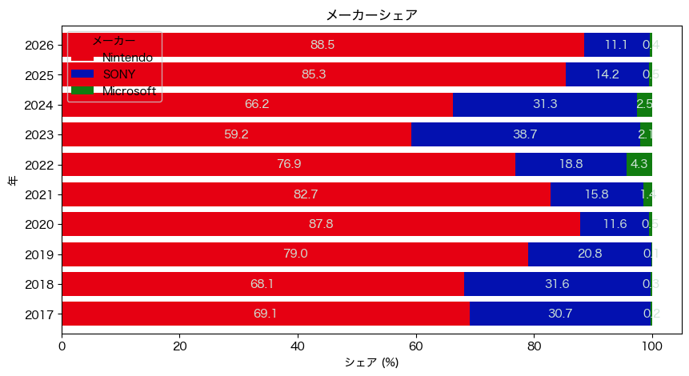

ぽこあポケモン効果継続で任天堂シェア88.5%が続いています｡